# Data simulation

## Defining variables

First lets define ‘independent’ variables that are drawn from a distribution rather than from the model. In this particular case, these variables are the ones that, given our DAG, do not have arrows coming into them (i.e. those variables that are not influenced by the model).

```r
set.seed(62)
n=5000
age = round(rnorm(n, mean =50, sd = 13),1)
immigrant = rbinom(n, 1, .15)
race = sample(c(rep('white',times = n *.7),rep('black', times = n*.2), rep('other',times=n*.1)))
```

Of note we established that, most likely the immigrant variable would be influenced by the ethnicity variable. And we can figure out a way to draw samples given ethnicity. However, for the first part of the exmample and for simplicity we will just create a binomial variable for immigrant.

## The model

Given the following DAG we established our data generation rule using an example f how Maria would create these data on STATA:

`generate mean_education = 12 - .1*age +2.5(age<50) * immigrant + (age>=50*immigrant) - black*immigrant - 1.5*other`

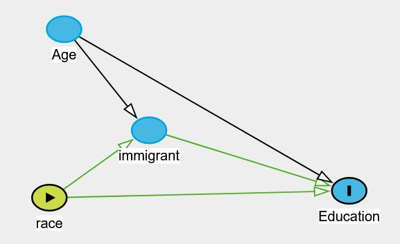

Data generating model

Now, the way I ‘relaxed’ the problem was to brake down each one of the variables and then putting them back on to the model so it can be translated to other software languages.

```r
x0 = 12

x1 = -.1*age

#I am not 100% sure about these but the syntax says:
#If a person is younger than 50, multiply 2.5*immigrant status, else assign 0 (i.e. This coefficient doesn't count)
x2 = ifelse(age<50,2.5*immigrant,0)

#If a person is 50 or older, just use immigrant status, else assign 0 (i.e. This coefficient doesn't count)
x3 = ifelse(age>=50, immigrant, 0)

#If a person's race is black assign a -1 else assign 0 (i.e. This coefficient doesn't count)
x4 = ifelse(race=="black",-1,0)

#If a person's race is other assign a -1.5 else assign 0 (i.e. This coefficient doesn't count)
x5 = ifelse(race=="other",-1.5,0)


mean_education = mean_education = x0 + x1 + x2 +x3 + x4 + x5
```

```r
mean_educ2 = 12 - (.1*age) + (age<50)*2.5*immigrant - (age>=50)*immigrant - 1*(race=='black') - 1.5*(race=="other")
```

Now we asssign a random term to education and combine it with the mean education

```r
random_education = rnorm(n)*3

education = mean_education + random_education
```

Since we established a rule for age where there is a cutoff we need to create a variable that reflects this cutoff (i.e making age binary)

```r
bin_age = as.numeric(age < 50)
```

To make easy reading the code we can put all these on a data frame

```r
data = data.frame(age,
                  immigrant,
                  race,
                  mean_education,
                  mean_educ2,
                  education,
                  bin_age,
                  x0,x1,x2,x3,x4,x5)
```

```r
head(data,20)
```

|  | age | immigrant | race | mean_education | mean_educ2 | education | bin_age | x0 | x1 | x2 | x3 | x4 | x5 |
| --- | --- | --- | --- | --- | --- | --- | --- | --- | --- | --- | --- | --- | --- |
| 1 | 60.4 | 0 | black | 4.96 | 4.96 | 3.456474 | 0 | 12 | -6.04 | 0.0 | 0 | -1 | 0.0 |
| 2 | 53.7 | 0 | white | 6.63 | 6.63 | 9.638749 | 0 | 12 | -5.37 | 0.0 | 0 | 0 | 0.0 |
| 3 | 30.3 | 0 | white | 8.97 | 8.97 | 8.950112 | 1 | 12 | -3.03 | 0.0 | 0 | 0 | 0.0 |
| 4 | 51.0 | 0 | white | 6.90 | 6.90 | 5.837630 | 0 | 12 | -5.10 | 0.0 | 0 | 0 | 0.0 |
| 5 | 79.4 | 1 | white | 5.06 | 3.06 | 8.130373 | 0 | 12 | -7.94 | 0.0 | 1 | 0 | 0.0 |
| 6 | 50.8 | 0 | white | 6.92 | 6.92 | 3.438652 | 0 | 12 | -5.08 | 0.0 | 0 | 0 | 0.0 |
| 7 | 61.9 | 0 | white | 5.81 | 5.81 | 7.836244 | 0 | 12 | -6.19 | 0.0 | 0 | 0 | 0.0 |
| 8 | 34.4 | 0 | white | 8.56 | 8.56 | 5.368242 | 1 | 12 | -3.44 | 0.0 | 0 | 0 | 0.0 |
| 9 | 51.3 | 1 | other | 6.37 | 4.37 | 4.031875 | 0 | 12 | -5.13 | 0.0 | 1 | 0 | -1.5 |
| 10 | 37.2 | 0 | white | 8.28 | 8.28 | 8.040282 | 1 | 12 | -3.72 | 0.0 | 0 | 0 | 0.0 |

[output cut: 10 more lines]

Let’s check the model!

```r
model_1 = lm(education ~age + immigrant + as.factor(race) + (bin_age*immigrant))

summary(model_1)
```

```
##
## Call:
## lm(formula = education ~ age + immigrant + as.factor(race) +
##     (bin_age * immigrant))
##
## Residuals:
##      Min       1Q   Median       3Q      Max
## -11.7245  -2.0549  -0.0307   2.0298  10.4984
##
## Coefficients:
##                       Estimate Std. Error t value Pr(>|t|)
## (Intercept)          10.955728   0.350179  31.286  < 2e-16 ***
## age                  -0.098153   0.005478 -17.919  < 2e-16 ***
## immigrant             1.136564   0.174672   6.507 8.43e-11 ***
## as.factor(race)other -0.397620   0.166828  -2.383   0.0172 *
## as.factor(race)white  0.880079   0.109210   8.059 9.58e-16 ***
## bin_age               0.127736   0.147399   0.867   0.3862
## immigrant:bin_age     1.011466   0.242908   4.164 3.18e-05 ***
## ---
## Signif. codes:  0 '***' 0.001 '**' 0.01 '*' 0.05 '.' 0.1 ' ' 1
##
## Residual standard error: 3.045 on 4993 degrees of freedom
## Multiple R-squared:  0.2187, Adjusted R-squared:  0.2178
## F-statistic:   233 on 6 and 4993 DF,  p-value: < 2.2e-16
```